# What happened to *Chocolate City*?

The Mathematics of Racial and Residential Segregation in Washington, DC

The Quant Shop + Nubian Hueman

**Project Team**:

Nathan Alexander (Howard University)

Anika Hobson (Nubian Hueman)

Zoe Williams (Howard University)

Qyana Stewart (Howard University)

[output not shown]

[output not shown]

```
## Simple feature collection with 206 features and 22 fields
## Geometry type: POLYGON
## Dimension:     XY
## Bounding box:  xmin: -77.11976 ymin: 38.79165 xmax: -76.9094 ymax: 38.99511
## Geodetic CRS:  NAD83
## First 10 features:
##        GEOID.x totalpopE    pwhite    pblack    pasian     phisp whiteE blackE
## 1  11001000201      2384 51.132550  8.515101 20.973154 12.961409   1219    203
## 2  11001010300      4196 16.587226 53.836988  1.263108 24.833174    696   2259
## 3  11001002801      3818 28.208486 20.481928  7.726558 37.585123   1077    782
## 4  11001004002      3146 69.993643  5.340114  5.276542 11.665607   2202    168
## 5  11001006700      4058 81.813701  9.241005  3.573189  4.509611   3320    375
## 6  11001007707      4131  2.662794 90.534979  0.000000  4.333091    110   3740
## 7  11001008803      3784 22.832981 56.844609  3.594080 13.239958    864   2151
## 8  11001009302      1762 29.171396 46.083995  1.191827 19.636776    514    812
```

[output cut: 35 more lines]

In our data, “totalpopE” is a single number representing the estimated population, while “totalpopM” represents a range around that estimate within which the true population is likely to fall. The designation for “E” and “M” follows in line as the estimate and the margin of error.

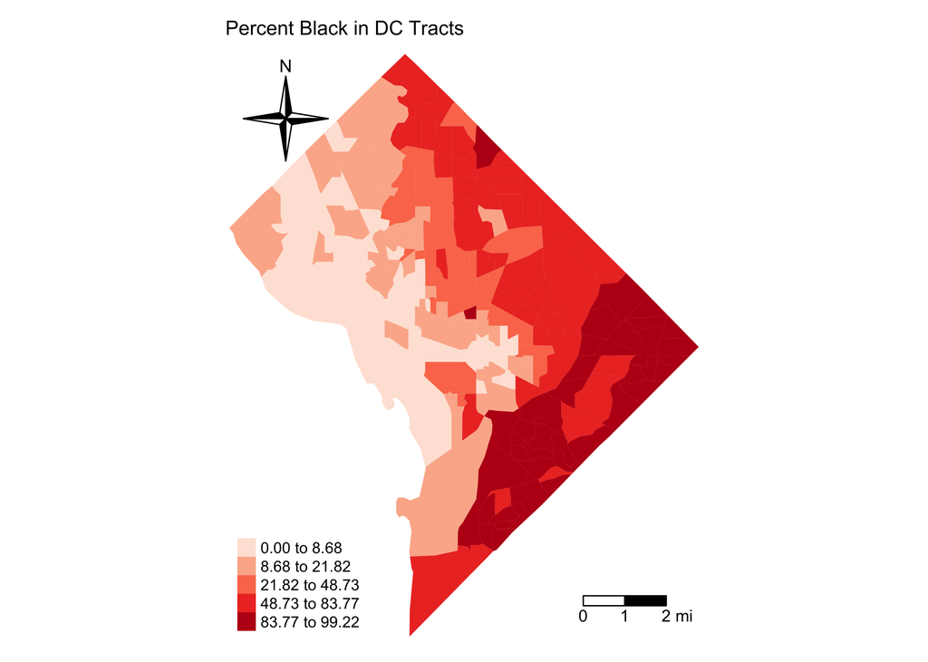

# OVERVIEW

Whatever happened to *Chocolate City*, the term used to refer to Washington DC’s Black population?

In this short report, we discuss some key historical and contemporary connections and then we analyze US census data to examine historical and continual shifts in Washington DC’s Black population. We focus on racial isolation and residential segregation. We close with a discussion on how modern critical theories, mathematics, and population-level data can increase our general knowledge as a community and inform our perspectives on local policies and social action issues, like voting and community service.

*The materials presented here are for the October 2024 workshop at Nubian Hueman studios in DC.*

# DATA

The discussions and analysis in this report are informed by the US Census microdata, which was accessed through the `tidycensus()` package in R. The American Community Survey (ACS) Public Use Microdata Sample (PUMS) is used to analyze pre-aggregate data at a local level. This data allowed us to make various custom estimates that may not be normally available by the US Census Bureau.

Learn more about the PUMAs [here](https://www.census.gov/programs-surveys/acs/microdata.html).

```
## # A tibble: 521 × 4
##    var_code var_label                                            data_type level
##    <chr>    <chr>                                                <chr>     <chr>
##  1 SERIALNO Housing unit/GQ person serial number                 chr       <NA>
##  2 DIVISION Division code based on 2010 Census definitions Divi… chr       <NA>
##  3 PUMA     Public use microdata area code (PUMA) based on 2020… chr       <NA>
##  4 REGION   Region code based on 2020 Census definitions         chr       <NA>
##  5 ST       State Code based on 2020 Census definitions          chr       <NA>
##  6 ADJHSG   Adjustment factor for housing dollar amounts (6 imp… chr       hous…
##  7 ADJINC   Adjustment factor for income and earnings dollar am… chr       hous…
##  8 WGTP     Housing Unit Weight                                  num       hous…
##  9 NP       Number of persons in this household                  num       hous…
## 10 TYPEHUGQ Type of unit                                         chr       hous…
## # ℹ 511 more rows
```

```
## # A tibble: 5,384 × 12
##    survey year  var_code var_label     data_type level val_min val_max val_label
##    <chr>  <chr> <chr>    <chr>         <chr>     <chr> <chr>   <chr>   <chr>
##  1 acs1   2022  SERIALNO Housing unit… chr       <NA>  2022GQ… 2022GQ… GQ Uniqu…
##  2 acs1   2022  SERIALNO Housing unit… chr       <NA>  2022HU… 2022HU… HU Uniqu…
##  3 acs1   2022  DIVISION Division cod… chr       <NA>  0       0       Puerto R…
##  4 acs1   2022  DIVISION Division cod… chr       <NA>  1       1       New Engl…
##  5 acs1   2022  DIVISION Division cod… chr       <NA>  2       2       Middle A…
##  6 acs1   2022  DIVISION Division cod… chr       <NA>  3       3       East Nor…
##  7 acs1   2022  DIVISION Division cod… chr       <NA>  4       4       West Nor…
##  8 acs1   2022  DIVISION Division cod… chr       <NA>  5       5       South At…
##  9 acs1   2022  DIVISION Division cod… chr       <NA>  6       6       East Sou…
## 10 acs1   2022  DIVISION Division cod… chr       <NA>  7       7       West Sou…
## # ℹ 5,374 more rows
## # ℹ 3 more variables: recode <lgl>, val_length <int>, val_na <dbl>
```

### Map: Washington, DC

[interactive chart not shown]